# Math Concepts 1

## Absolute

- The absolute value of a number $x$ is the non-negative value of it.
- Denoted with $|x|$.
- $|-x| = |x| = x$.
- Examples:
  - $|2| = 2$
  - $|-5| = 5$

## Square

- Product of a number $x$ with itself.
- Denoted with superscript $^2 \rightarrow x^2$
- Examples:
  - $2^2 = 2 * 2 = 4$
  - $5^2 = 5 * 5 = 25$

[figure not shown]

## Square Root

- A number $y$ whose square is $x$.
- So, $y^2=x$.
- Denoted by $y=\sqrt{x}$.
- Examples:
  - $\sqrt{4}=2$, as $2^2=4$.
  - $\sqrt{25}=5$, as $5^2=25$.

## Summation

- The process of adding a sequence of numbers together.
- Applies a loop of summations.
- Expression: $\sum_{i=0}^{n}$, where:
  - Σ: Greek letter sigma, represents summation.
  - $i=0$ to $n$: Limits of summation, starting at $0$ and finishing at $n$.
- Example 1:
  - Sum of all integers from $0$ ($i=0$) to $5$ ($n=5$), which equals $15$.
  - $\sum_{i=0}^{n=5}{i} = 0 + 1 + 2 + 3 + 4 + 5 = 15$
- Example 2: Given a vector $v = [3, 5, 1]$, where $n=\text{length of } v = 3$,
  - $\sum_{i=0}^{n}{v_{(i)}} = 3 + 5 + 1 = 9$
  - When the values of $i$ and $n$ are unmistakable, we normally omit them and just write:
  - $\sum{v_{(i)}}$, or even $\sum{v}$

## Dimensionality

[figure not shown]

### 1D

- 1D can be visualized as a straight line.
- Every point is identified with a single coordinate (often called $x$).
- Can display one variable.
  - Example: house m²

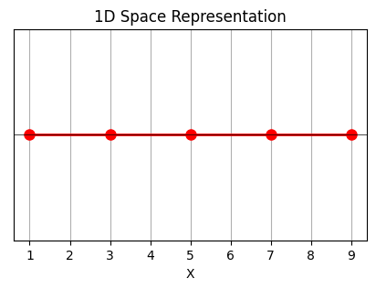

```python
# 1D points
plot1d([1, 3, 5, 7, 9])
```

### 2D

- Every point is identified by 2 coordinates (often called $x$ and $y$).
- Can display 2 variables.
  - Example: house m² and house price.

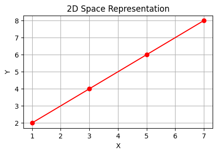

```python
# 2D points
plot2d([(1, 2), (3, 4), (5, 6), (7, 8)])
```

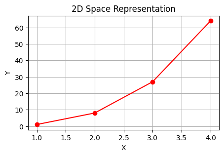

```python
# 2D curved points
plot2d([(1, 1), (2, 8), (3, 27), (4, 64)])
```

### 3D

- Our everyday space reality.
- Every point is identified by 3 coordinates (often called $x$, $y$, and $z$).
- Can display 3 variables.
  - Example: house m², number of rooms, and house price.

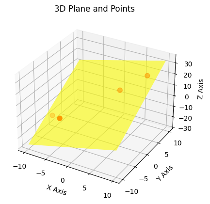

```python
plot3d()
```

### ND

- ND spaces are beyond our visualization but are crucial in computational mathematics and scientific research.
- Every point is identified by $N$ coordinates.
- Composed of $N$ variables.
  - Example: house m², number of rooms, number of bathrooms, house price, etc.

## Linear Algebra

- A branch of mathematics that deals with vectors, vector spaces, linear transformations, and systems of linear equations.
- Fundamental in computer graphics, engineering, machine learning, physics, and more.
- Basic concepts:
  - Vectors: $[3, 2]$
  - Matrices: $\begin{pmatrix}1 & 2 \\3 & 4\end{pmatrix}$
  - Tensors

### Example 1

- A small business owner sells two types of custom-made candles: lavender and rose.
- The price of a lavender candle is 5€ and the price of a rose candle is 6€.
- One day, the owner sells a total of 40 candles and earns 220€.
- How many of each type of candle were sold?
- Let $x$ be the number of lavender candles sold.
- Let $z$ be the number of rose candles sold.
- We can create the following equations based on the given information:

$x + z = 40$ (Total number of candles sold)

$5x + 6z = 220$ (Total earnings from candles sold)

- We can write these equations in matrix form $AX = B$, where
  - $A$ is the coefficient matrix,
  - $X$ is the variable matrix, and
  - $B$ is the constant matrix.

$A = \begin{pmatrix} 1 & 1 \\ 5 & 6 \end{pmatrix}$

$X = \begin{pmatrix} x \\ z \end{pmatrix}$

$B = \begin{pmatrix} 40 \\ 220 \end{pmatrix}$

- Solve for $X$ (the matrix of variables):

$X = A^{-1}B$

- Find the inverse of matrix $A$:

$A^{-1} = \begin{pmatrix} 6 & -1 \\ -5 & 1 \end{pmatrix}$

- Multiply $A^{-1}$ by $B$:

$X = \begin{pmatrix} 6 & -1 \\ -5 & 1 \end{pmatrix} \begin{pmatrix} 40 \\ 220 \end{pmatrix} = \begin{pmatrix} 20 \\ 20 \end{pmatrix}$

- The business owner sold `20` lavender candles and `20` rose candles.

```python
# Define the coefficient matrix A and the constant matrix B
A = np.array([[1, 1],
              [5, 6]])

B = np.array([40, 220])

X = np.matmul(np.linalg.inv(A), B)

print(X)
print(f'Number of lavender candles sold: {int(round(X[0]))}')
print(f'Number of rose candles sold: {int(round(X[1]))}')
```

```
[20. 20.]
Number of lavender candles sold: 20
Number of rose candles sold: 20
```

### Example 2

Matrices can be used to perform geometric transformations, such as rotations, translations, scalings, stretchings, etc.

The original vertices of the square are defined as follows:

$vertices = \begin{pmatrix}0 & 0 \\0 & 1 \\1 & 1 \\1 & 0 \\0 & 0\end{pmatrix}$

The last point is to close the square when we plot it.

```python
vertices = np.array([[0, 0], [0, 1], [1, 1], [1, 0], [0, 0]])
```

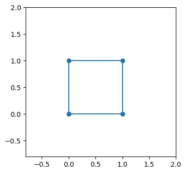

```python
plt.figure(figsize=(4, 4))

# Plot the original square
plt.plot(vertices[:, 0], vertices[:, 1], marker='o')
plt.xlim(-0.8, 2)
plt.ylim(-0.8, 2)

# Show the plot
plt.show()
```

#### Scaling

Multiply the matrix by the scaling factor $\lambda$. For example, $\lambda = 1.5$, so the resulting square is 50% greater than the original.

$scaled = \lambda \cdot vertices = 1.5 \cdot \begin{pmatrix}0 & 0 \\0 & 1 \\1 & 1 \\1 & 0 \\0 & 0\end{pmatrix} = \begin{pmatrix}0 & 0 \\0 & 1.5 \\1.5 & 1.5 \\1.5 & 0 \\0 & 0\end{pmatrix}$

```python
lam = 1.5
scaled_square = lam * vertices
```

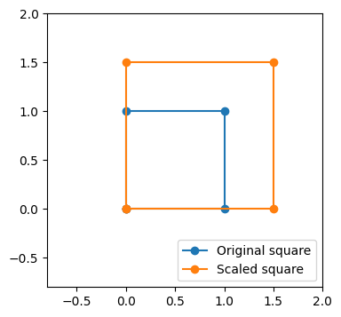

```python
plt.figure(figsize=(4, 4))

# Plot the original square
plt.plot(vertices[:, 0], vertices[:, 1], marker='o', label='Original square')
plt.plot(scaled_square[:, 0], scaled_square[:, 1], marker='o', label='Scaled square')
plt.xlim(-0.8, 2)
plt.ylim(-0.8, 2)

# Show the plot
plt.legend(loc='lower right')
plt.show()
```

#### Translation

Add a matrix with the factor we want to apply for the translation. For example, for an horizontal translation, we perform an operation element-wise, adding 0.5 to the x-coordinate of each vertex and 0 to the y-coordinate of each vertex:

$T = \begin{pmatrix}0.5 & 0\\0.5 & 0\\0.5 & 0\\0.5 & 0\\0.5 & 0\end{pmatrix}$

$h\_trans = vertices + T = \begin{pmatrix}0 & 0 \\0 & 1 \\1 & 1 \\1 & 0 \\0 & 0\end{pmatrix} + \begin{pmatrix}0.5 & 0\\0.5 & 0\\0.5 & 0\\0.5 & 0\\0.5 & 0\end{pmatrix} = \begin{pmatrix}0.5 & 0 \\0.5 & 1 \\1.5 & 1 \\1.5 & 0 \\0.5 & 0\end{pmatrix}$

```python
# Horizontal translation by 0.5
HT = np.array([0.5, 0])
h_trans = vertices + HT
```

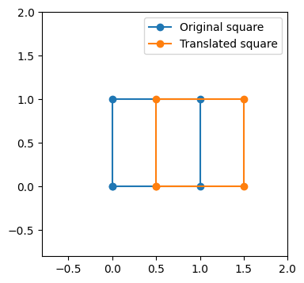

```python
plt.figure(figsize=(4, 4))

# Plot the original square
plt.plot(vertices[:, 0], vertices[:, 1], marker='o', label='Original square')
plt.plot(h_trans[:, 0], h_trans[:, 1], marker='o', label='Translated square')
plt.xlim(-0.8, 2)
plt.ylim(-0.8, 2)

# Show the plot
plt.legend()
plt.show()
```

For a vertical translation:

$T = \begin{pmatrix}0 & 0.5\\0 & 0.5\\0 & 0.5\\0 & 0.5\\0 & 0.5\end{pmatrix}$

$h\_trans = vertices + T = \begin{pmatrix}0 & 0 \\0 & 1 \\1 & 1 \\1 & 0 \\0 & 0\end{pmatrix} + \begin{pmatrix}0 & 0.5\\0 & 0.5\\0 & 0.5\\0 & 0.5\\0 & 0.5\end{pmatrix} = \begin{pmatrix}0 & 0.5 \\0 & 1.5 \\1 & 1.5 \\1 & 0.5 \\0 & 0.5\end{pmatrix}$

```python
# Vertical translation by 0.5
VT = np.array([0, 0.5])
v_trans = vertices + VT
```

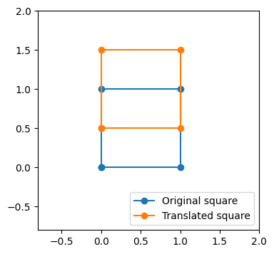

```python
plt.figure(figsize=(4, 4))

# Plot the original square
plt.plot(vertices[:, 0], vertices[:, 1], marker='o', label='Original square')
plt.plot(v_trans[:, 0], v_trans[:, 1], marker='o', label='Translated square')
plt.xlim(-0.8, 2)
plt.ylim(-0.8, 2)

# Show the plot
plt.legend(loc='lower right')
plt.show()
```

For a uniform translation:

$T = \begin{pmatrix}0.5 & 0.5\\0.5 & 0.5\\0.5 & 0.5\\0.5 & 0.5\\0.5 & 0.5\end{pmatrix}$

$h\_trans = vertices + T = \begin{pmatrix}0 & 0 \\0 & 1 \\1 & 1 \\1 & 0 \\0 & 0\end{pmatrix} + \begin{pmatrix}0.5 & 0.5\\0.5 & 0.5\\0.5 & 0.5\\0.5 & 0.5\\0.5 & 0.5\end{pmatrix} = \begin{pmatrix}0.5 & 0.5 \\0.5 & 1.5 \\1.5 & 1.5 \\1.5 & 0.5 \\0.5 & 0.5\end{pmatrix}$

```python
# Translation by 0.5
T = np.array([0.5, 0.5])
trans = vertices + T
```

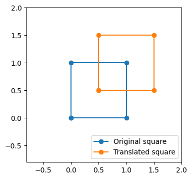

```python
plt.figure(figsize=(4, 4))

# Plot the original square
plt.plot(vertices[:, 0], vertices[:, 1], marker='o', label='Original square')
plt.plot(trans[:, 0], trans[:, 1], marker='o', label='Translated square')
plt.xlim(-0.8, 2)
plt.ylim(-0.8, 2)

# Show the plot
plt.legend(loc='lower right')
plt.show()
```

#### Rotation

The angle of rotation $\theta$ is defined as $\frac{\pi}{4}$ radians for a 45-degree counterclockwise rotation:

```python
theta = np.pi / 4
```

Define the Rotation Matrix $R$:

$R = \begin{pmatrix}\cos(\theta) & -\sin(\theta) \\ \sin(\theta) & \cos(\theta)\end{pmatrix}$

```python
R = np.array([[np.cos(theta), -np.sin(theta)],
              [np.sin(theta), np.cos(theta)]])
```

- The rotation transformation is applied to each vertex of the square.
- Multiplying the rotation matrix $R$ with the vertices matrix.
- Note that $R$ is transposed to ensure correct matrix multiplication.

```python
# Transpose R for correct matrix multiplication
rotated_vertices = np.dot(vertices, R.T)
```

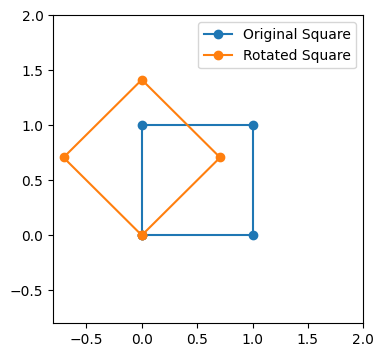

```python
plt.figure(figsize=(4, 4))
# Plot the original square
plt.plot(vertices[:, 0], vertices[:, 1], marker='o', label='Original Square')

# Plot the rotated square
plt.plot(rotated_vertices[:, 0], rotated_vertices[:, 1], marker='o', label='Rotated Square')
set_plot_options()
# Show the plot
plt.show()
```

#### Computer Games

- Basically, computer graphics work with matrices under the hood.
- In 3D calculations are a bit more complex than the previous 2D transformations.
- The GPU is optimized for performing matrix operations at high speed.
- When you play a video game, the GPU is constantly performing matrix transformations to calculate:
  - Positions, orientations, and projections of objects,
  - Lighting, shading, etc.